# Hemocentro

Pablo Gilvan Borges

Análise da base de dados do hemocentro de Porto Alegre. Estes dados compoem a base de dados referênte a doações feitas no ano de 2015 até início de 2018. Todo os dados foram obtidos com permissão da diretoria do hospital. Conseguimos os dados pois estou iniciando um grupo de estudos na Universidade Feevale, junto com outros alunos, para que consigamos, através de uma análise extensa e minuciosa, gerar valor para o hospital traçando perfís de doadores e tentando encontrar padrões que ocasionaram tanto doações como perdas de materiais. A análise que se segue foi toda feita por minha pessoa com a finalidade de servir como overview e início das pesquisas para o grupo aqui citado.

Fontes externas:  
https://www.fee.rs.gov.br/indicadores/populacao/estimativas-populacionais/

#### Carregando bibliotecas

```r
library(tidyverse)
library(gridExtra)
library(readr)
library(stringr)
library(reshape2)
library(stringi)
library(lubridate)
# SE ESTIVER USANDO MAC, Setando Encoding
Sys.setlocale("LC_ALL", "pt_BR.UTF-8")
```

```
## [1] "LC_CTYPE=pt_BR.UTF-8;LC_NUMERIC=C;LC_TIME=pt_BR.UTF-8;LC_COLLATE=pt_BR.UTF-8;LC_MONETARY=pt_BR.UTF-8;LC_MESSAGES=pt_BR.UTF-8;LC_PAPER=pt_BR.UTF-8;LC_NAME=C;LC_ADDRESS=C;LC_TELEPHONE=C;LC_MEASUREMENT=pt_BR.UTF-8;LC_IDENTIFICATION=C"
```

### Carregando dados

#### Listando uma amostra dos dados para ver se está tudo ok.

```r
doacoes <- read.csv2(file = 'doacoes.csv', stringsAsFactors=FALSE, fileEncoding="cp857", sep = ",")
head(doacoes)
```

|  | raca | sexo | data_nasc | estado_civil | escolaridade | profissao | cor | c_residencial | b_residencial | c_profissional | b_profissional | naturalidade | nacionalidade | abo_doador | rh_doador | DOD_HemoglobinaS | DOD_CDE | PAI | dt_doacao | tipo_doacao | campanha | desistencia_doacao | DOA_Peso | DOA_Altura | DOA_Temperatura | DOA_Pulso | DOA_Hemoglobina | DOA_PressaoArterial1 | DOA_PressaoArterial2 | … |
| --- | --- | --- | --- | --- | --- | --- | --- | --- | --- | --- | --- | --- | --- | --- | --- | --- | --- | --- | --- | --- | --- | --- | --- | --- | --- | --- | --- | --- | --- | --- |
| 1 | NULL | M | 09/04/1961 | Ñ.Inf | Ens. Medio Completo | OUTROS | NULL | PORTO ALEGRE | RUBEM BERTA | PORTO ALEGRE | RIO BRANCO | ´PORTO ALEGRE | Brasil | O | + | NULL | + | N | 08/05/2015 | PLAQUETAFERESE ESPONTANEA | NULL | N | NULL | 1650 | 36000 | 92000 | 14000 | 113000 | 79000 | … |
| 2 | Branco | M | 15/02/1993 | Solteiro | Ens. Medio Completo | Vendedor | M4 | GRAVATAI | PARQUE IPIRANGA | PORTO ALEGRE | RIO BRANCO | ´PORTO ALEGRE | Brasil | O | + | NULL | + | N | 27/06/2015 | SANGUE TOTAL REPOSICAO | NULL | N | NULL | 1650 | 37000 | 77000 | 17000 | 137000 | 68000 | … |
| 3 | Branco | M | 11/12/1956 | Casado | Ens. Medio Completo | Vendedor | M3 | ESTEIO | Centro | PORTO ALEGRE | RIO BRANCO | ´PORTO ALEGRE | Brasil | A | + | NULL | + | N | 02/06/2015 | SANGUE TOTAL REPOSICAO | NULL | N | NULL | 1750 | 36000 | 85000 | 15000 | 160000 | 78000 | … |
| 4 | Branco | M | 17/05/1974 | Casado | Ens. Fundamental Completo | OUTROS | M4 | PORTO ALEGRE | NULL | PORTO ALEGRE | RIO BRANCO | CAMAQUÃ | BRASILEIRO | A | - | NULL | 0 | N | 28/04/2015 | SANGUE TOTAL REPOSICAO | NULL | N | NULL | 1750 | 36000 | 80000 | 15000 | 146000 | 98000 | … |
| 5 | Branco | M | 19/10/1982 | Casado | Ens. Fundamental Incompleto | Vendedor | M4 | PORTO ALEGRE | CORONEL APARICIO BORGES | PORTO ALEGRE | RIO BRANCO | SOBRADINHO | BRASILEIRO | O | + | NULL | + | N | 11/05/2015 | SANGUE TOTAL REPOSICAO | NULL | N | NULL | 1770 | 36000 | 64000 | 14000 | 141000 | 86000 | … |
| 6 | Branco | F | 21/10/1980 | Solteiro | Ens. Medio Incompleto | ENGENHEIRA | M3 | PORTO ALEGRE | SAO JOSE | PORTO ALEGRE | RIO BRANCO | TAPES | BRASILEIRO | O | + | Ausente | + | N | 07/07/2015 | PLAQUETAFERESE ESPONTANEA | NULL | N | NULL | 1690 | 36000 | 71000 | 14000 | 132000 | 80000 | … |

Perfeito, tive que rastrear o encoding correto para o arquivo, o cp857 foi o único que conseguiu carregar os dados com acentuação correta.

Quantidade de registros

```r
nrow(doacoes)
```

```
## [1] 197047
```

Parece que alguns valores na tabela de doações estão com acentuação e outros não, outros estão com valores totalmente fora do contexto, como esperado pela leitura externa, então vamos ter que trabalhar estes dados para termos consistência ao gerar gráficos e agrupamentos.

Primeiro vamos renomear estas colunas, os nomes atuais não deixam o código refletir o real sentido do que está sendo feito.

```r
colnames(doacoes)[colnames(doacoes)=="c_residencial"] <- "cidade"
colnames(doacoes)[colnames(doacoes)=="b_residencial"] <- "bairro"

#Seto o nome das colunas para maiúsculo, acho melhor de trabalhar e visualizar no codigo.
colnames(doacoes) <- toupper(colnames(doacoes))
```

#### Trabalhando a questão da acentuação.

```r
#Removendo acentuação.
doacoes$CIDADE <- stri_trans_general(doacoes$CIDADE,"Latin-ASCII")


#Convertemos colunas categóricas para factor para que consigamos agrupar os valores como categorias nos gráficos.
doacoes$CIDADE <- as.factor(doacoes$CIDADE)
doacoes$CIDADE <- toupper(doacoes$CIDADE)
doacoes$ABO_DOADOR <- as.factor(doacoes$ABO_DOADOR)
```

## Doações

Vamos analisar o perfil dos usuários, levando em conta coisas como Cidade, Bairros, Idade, Sexo e Tipo de Doação. A ideia em sí é tentar achar um padrão de doadores e demais padrões que possam se apresentar.

### Doações por cidade

Começamos então traçando o perfil por cidade. Quais as cidades com maior quantidade de doadores? O que poderia ter influênciado tal quantidade de doações?  
#### Sumário dos dados Vamos listar um sumário dos dados, ter uma ideia do conjunto de dados que temos pela frente.

```r
summary(doacoes)
```

```
##      RACA               SEXO            DATA_NASC
##  Length:197047      Length:197047      Length:197047
##  Class :character   Class :character   Class :character
##  Mode  :character   Mode  :character   Mode  :character
##
##
##
##
##  ESTADO_CIVIL       ESCOLARIDADE        PROFISSAO
##  Length:197047      Length:197047      Length:197047
##  Class :character   Class :character   Class :character
##  Mode  :character   Mode  :character   Mode  :character
##
##
##
##
##      COR               CIDADE             BAIRRO
##  Length:197047      Length:197047      Length:197047
##  Class :character   Class :character   Class :character
##  Mode  :character   Mode  :character   Mode  :character
##
##
##
##
##  C_PROFISSIONAL     B_PROFISSIONAL     NATURALIDADE
##  Length:197047      Length:197047      Length:197047
##  Class :character   Class :character   Class :character
##  Mode  :character   Mode  :character   Mode  :character
##
##
##
##
##  NACIONALIDADE        ABO_DOADOR     RH_DOADOR         DOD_HEMOGLOBINAS
##  Length:197047      O      :97445   Length:197047      Length:197047
##  Class :character   A      :73556   Class :character   Class :character
##  Mode  :character   B      :18548   Mode  :character   Mode  :character
##                     AB     : 7236
##                     0      :  132
##                     NULL   :  102
##                     (Other):   28
```

[output cut: 113 more lines]

```
##  Length:197047      Length:197047      Length:197047
##  Class :character   Class :character   Class :character
##  Mode  :character   Mode  :character   Mode  :character
##
##
##
##
##       X
##  Length:197047
##  Class :character
##  Mode  :character
##
##
##
##
```

Ok, vamos focar em um dado mais específico: Tipo sanguíneo(ABO_DOADOR). O sumário aponta alguns tipos sanguineos diferente dos existentes, vamos listar somente isso para ver quais valores temos.

```r
summary(doacoes$ABO_DOADOR)
```

```
##      0      A     AB      B Brasil      I      N   NULL      O     O
##    132  73556   7236  18548      7     12      4    102  97445      5
```

Ok, temos 102 valores nulos, 132 valores Zero, 7 valores como ‘Brasil’, 5 valores ‘O’ com espaçamento a direita, 4 valores N e 12 vaores ‘I’. Temos que decidir ou não remover estes dados. Como temos vários registros e no momento não queremos analisar o tipo sanguineo e sim focar nas doações, vamos deixar esses valores, pois removê-los nos traria um impacto que não necessitamos no momento.  
Vamos primeiro ajustar os valores ‘O’ com espaçamento para o valor correto.

```r
doacoes$ABO_DOADOR[doacoes$ABO_DOADOR == "O "] <- "O"
summary(doacoes$ABO_DOADOR)
```

```
##      0      A     AB      B Brasil      I      N   NULL      O     O
##    132  73556   7236  18548      7     12      4    102  97450      0
```

## Analisando o perfil do doador: Cidades e Proporção de doações

Vamos agora analisar os valores de doados por município, analisar não somente a quantidade doações, mas a proporção de doações baseando-se na quantidade populacional e a quantidade de doações, pois seria injusto dizer que Porto Alegre é a cidade que mais contribui para a reposição de sangue quando a mesma tem muito mais habitantes que as demais cidades.

Primeiro temos que conseguir o valor populacional. Não podemos simplesmente pegar o valor populacional, mas sim o valor populacional da faixa etária aceitável para doações. Navegando até o site: https://www.fee.rs.gov.br/wp-content/uploads/2014/03/20170831populacao-municipio-sexo-fx-etaria.xls conseguimos os valores referênte ao estado do RS, o estado que nos interessa, visto que o hospital tem como foco os hospitais do estado, por mais que ainda forneça para outros estados o foco é estadual.

O dataset fornecido pelo link nos traz os dados agrupados por faixa etária. Agrupei, via excel mesmo, os valores referênte a faixa etária de 14 a 69 anos, tive que partir dos 14 anos pois o grupo do pessoal de 18 anos está contido nessa faixa etária.

Vamos começar a analisar a questão das cidades.

#### Valores de cidades - Dataset Doações

```r
cidades <- doacoes %>%
  subset(!is.null(CIDADE) & CIDADE != 'NULL')

# Salvamos temporariamente o dataframe filtrado na variável 'cidades', assim evitamos de ter várias coisas na memória, contando que temos uma quantidade grande de dados(para um computador convencional).
cidades <- table(cidades$CIDADE)
head(cidades)
```

```
##
## AGUAS CLARAS (VIAMAO)                 AGUDO             AJURICABA
##                    62                    96                     6
##              ALEGRETE              ALPESTRE           ALTO ALEGRE
##                    16                     5                    10
```

#### Quantidade de cidades

```r
length(cidades)
```

```
## [1] 398
```

Agora vamos pegar esse agrupamento de Cidade/Doacoes que está em formato Table e transformar para um Dataframe, para conseguir melhor trabalhar com os dados.

```r
cidades <- as.data.frame(cidades)
colnames(cidades) <- c("Cidade", "Doacoes")
head(cidades)
```

|  | Cidade | Doacoes |
| --- | --- | --- |
| 1 | AGUAS CLARAS (VIAMAO) | 62 |
| 2 | AGUDO | 96 |
| 3 | AJURICABA | 6 |
| 4 | ALEGRETE | 16 |
| 5 | ALPESTRE | 5 |
| 6 | ALTO ALEGRE | 10 |

#### Ordenando as 10 principais cidades com mais doadores Ok, temos bastante registros para plotar e não teríamos como exibir toda essa quantidade de valores únicos em um gráfico, não de forma que ficasse de fácil visualização. Vamos começar listando as 10 cidades com maior quantidade de doadores.  
Como já podemos imaginar, as cidades com maior quantidade populacional vão se destacar nesse gráfico, mas mesmo assim vamos listá-las.

```r
order.donnations <- with(cidades, order(-Doacoes))
first_ten <- head(cidades[order.donnations,],  10)
first_ten
```

|  | Cidade | Doacoes |
| --- | --- | --- |
| 267 | PORTO ALEGRE | 92478 |
| 62 | CANOAS | 11089 |
| 387 | VIAMAO | 8783 |
| 143 | GRAVATAI | 7911 |
| 9 | ALVORADA | 6137 |
| 50 | CACHOEIRINHA | 4982 |
| 343 | SAPUCAIA DO SUL | 4739 |
| 329 | SAO LEOPOLDO | 4287 |
| 122 | ESTEIO | 3329 |
| 232 | NOVO HAMBURGO | 3222 |

Acima podemos notar todas as cidades que compoem o Vale dos Sinos e a Grande Porto Alegre, o polo de cidades central do estado.

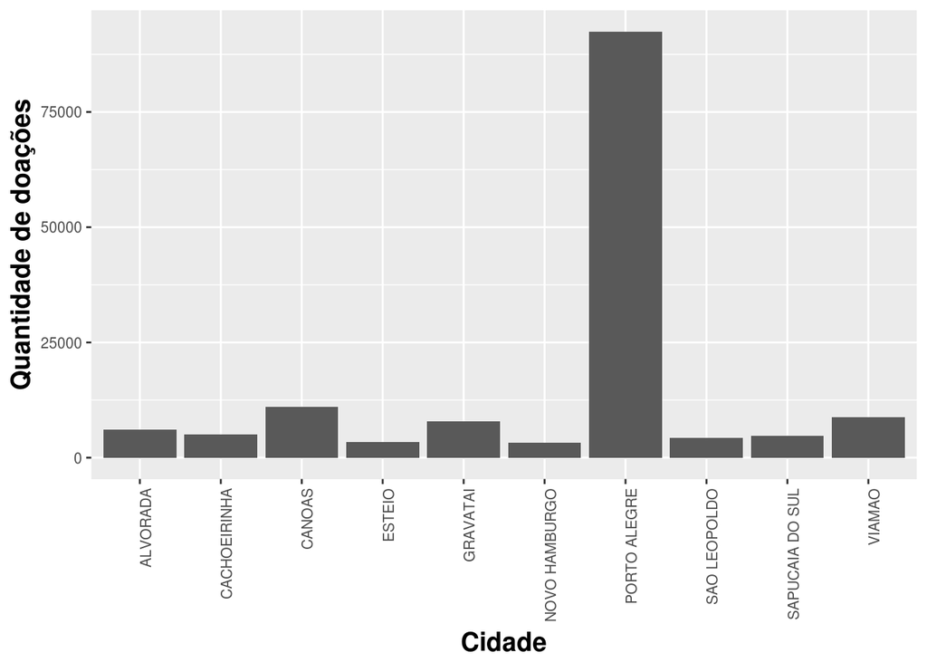

```r
first_ten %>%
  ggplot(mapping = aes(x = Cidade, y = Doacoes))+
  geom_col() +
  ylab("Quantidade de doações")+
  theme(axis.text=element_text(size=8),
        axis.text.x = element_text(angle = 90, hjust = 1),
        axis.title=element_text(size=14,face="bold"))
```

Bom, nada de mais, é de esperar que tais cidades apareçam como as cidades com maior quantidade de doadores, visto sua população. Vamos partir para algo mais interessante: vamos analisar as 10 cidades onde temos uma proporção de doações maior, em relação a quantidade de habitantes.

#### Comparando o percentual de doações baseando-se na quantidade de habitantes.

Vamos começar carregando o indicador populacional por cidades do estado do RS. Para isso vamos usar o conjunto de dados citados acima, já trabalhado para que forneça os dados necessários.

```r
pop_cidades <- read.csv2(file = '20170831populacao-municipio-sexo-fx-etaria2.csv', sep = ",")

#Vamos validar a classe das colunas
#lapply(pop_cidades, class)

head(pop_cidades)
```

|  | CÓDIGO | MUNICÍPIO | TOTAL | Homens | Mulheres | Homens...DE.15.A.19.ANOS | Mulheres...DE.15.A.19.ANOS | Homens...DE.20.A.24.ANOS | Mulheres...DE.20.A.24.ANOS | Homens...DE.25.A.29.ANOS | Mulheres...DE.25.A.29.ANOS | Homens...DE.30.A.34.ANOS | Mulheres...DE.30.A.34.ANOS | Homens...DE.35.A.39.ANOS | Mulheres...DE.35.A.39.ANOS | Homens...DE.40.A.44.ANOS | Mulheres...DE.40.A.44.ANOS | Homens...DE.45.A.49.ANOS | Mulheres...DE.45.A.49.ANOS | Homens...DE.50.A.54.ANOS | Mulheres...DE.50.A.54.ANOS | Homens...DE.55.A.59.ANOS | Mulheres...DE.55.A.59.ANOS | Homens...DE.60.A.64.ANOS | Mulheres...DE.60.A.64.ANOS | Homens...DE.65.A.69.ANOS | Mulheres...DE.65.A.69.ANOS | Homens...DE.70.A.74.ANOS | Mulheres...DE.70.A.74.ANOS |
| --- | --- | --- | --- | --- | --- | --- | --- | --- | --- | --- | --- | --- | --- | --- | --- | --- | --- | --- | --- | --- | --- | --- | --- | --- | --- | --- | --- | --- | --- |
| 1 | 430003 | Aceguá | 3458 | 1806 | 1652 | 208 | 224 | 186 | 166 | 164 | 147 | 159 | 144 | 153 | 160 | 181 | 129 | 151 | 162 | 169 | 136 | 157 | 126 | 113 | 111 | 100 | 79 | 65 | 68 |
| 2 | 430005 | Água Santa | 3107 | 1565 | 1542 | 167 | 161 | 175 | 177 | 153 | 161 | 163 | 146 | 109 | 126 | 131 | 127 | 140 | 135 | 137 | 139 | 127 | 131 | 108 | 117 | 90 | 73 | 65 | 49 |
| 3 | 430010 | Agudo | 13158 | 6707 | 6451 | 639 | 577 | 637 | 620 | 617 | 573 | 675 | 611 | 606 | 574 | 603 | 605 | 649 | 573 | 638 | 571 | 539 | 546 | 484 | 482 | 381 | 406 | 239 | 313 |
| 4 | 430020 | Ajuricaba | 5736 | 2838 | 2898 | 236 | 267 | 272 | 256 | 281 | 264 | 247 | 242 | 225 | 237 | 251 | 278 | 277 | 282 | 325 | 277 | 235 | 273 | 195 | 208 | 162 | 172 | 132 | 142 |
| 5 | 430030 | Alecrim | 5251 | 2555 | 2696 | 222 | 254 | 255 | 258 | 149 | 185 | 125 | 148 | 169 | 164 | 217 | 203 | 207 | 221 | 279 | 265 | 274 | 271 | 239 | 286 | 249 | 240 | 170 | 201 |
| 6 | 430040 | Alegrete | 58791 | 29036 | 29755 | 3128 | 2932 | 3267 | 3017 | 3007 | 2721 | 2747 | 2725 | 2429 | 2635 | 2355 | 2531 | 2520 | 2702 | 2677 | 2780 | 2278 | 2530 | 1935 | 2080 | 1526 | 1770 | 1167 | 1332 |

Bom, os nomes das cidades estão em formato normal quando que os do nosso dataset de doações estão todos em caixa alta. Vamos ter que trabalhar os dos dois, pois parece que alguns dos registros do dataset de doações não estão em caixa alta, fora a questão de acentuação.

```r
pop_cidades$MUNICÍPIO <- str_to_upper(pop_cidades$MUNICÍPIO)
pop_cidades$MUNICÍPIO <- stri_trans_general(pop_cidades$MUNICÍPIO,"Latin-ASCII")

head(pop_cidades)
```

|  | CÓDIGO | MUNICÍPIO | TOTAL | Homens | Mulheres | Homens...DE.15.A.19.ANOS | Mulheres...DE.15.A.19.ANOS | Homens...DE.20.A.24.ANOS | Mulheres...DE.20.A.24.ANOS | Homens...DE.25.A.29.ANOS | Mulheres...DE.25.A.29.ANOS | Homens...DE.30.A.34.ANOS | Mulheres...DE.30.A.34.ANOS | Homens...DE.35.A.39.ANOS | Mulheres...DE.35.A.39.ANOS | Homens...DE.40.A.44.ANOS | Mulheres...DE.40.A.44.ANOS | Homens...DE.45.A.49.ANOS | Mulheres...DE.45.A.49.ANOS | Homens...DE.50.A.54.ANOS | Mulheres...DE.50.A.54.ANOS | Homens...DE.55.A.59.ANOS | Mulheres...DE.55.A.59.ANOS | Homens...DE.60.A.64.ANOS | Mulheres...DE.60.A.64.ANOS | Homens...DE.65.A.69.ANOS | Mulheres...DE.65.A.69.ANOS | Homens...DE.70.A.74.ANOS | Mulheres...DE.70.A.74.ANOS |
| --- | --- | --- | --- | --- | --- | --- | --- | --- | --- | --- | --- | --- | --- | --- | --- | --- | --- | --- | --- | --- | --- | --- | --- | --- | --- | --- | --- | --- | --- |
| 1 | 430003 | ACEGUA | 3458 | 1806 | 1652 | 208 | 224 | 186 | 166 | 164 | 147 | 159 | 144 | 153 | 160 | 181 | 129 | 151 | 162 | 169 | 136 | 157 | 126 | 113 | 111 | 100 | 79 | 65 | 68 |
| 2 | 430005 | AGUA SANTA | 3107 | 1565 | 1542 | 167 | 161 | 175 | 177 | 153 | 161 | 163 | 146 | 109 | 126 | 131 | 127 | 140 | 135 | 137 | 139 | 127 | 131 | 108 | 117 | 90 | 73 | 65 | 49 |
| 3 | 430010 | AGUDO | 13158 | 6707 | 6451 | 639 | 577 | 637 | 620 | 617 | 573 | 675 | 611 | 606 | 574 | 603 | 605 | 649 | 573 | 638 | 571 | 539 | 546 | 484 | 482 | 381 | 406 | 239 | 313 |
| 4 | 430020 | AJURICABA | 5736 | 2838 | 2898 | 236 | 267 | 272 | 256 | 281 | 264 | 247 | 242 | 225 | 237 | 251 | 278 | 277 | 282 | 325 | 277 | 235 | 273 | 195 | 208 | 162 | 172 | 132 | 142 |
| 5 | 430030 | ALECRIM | 5251 | 2555 | 2696 | 222 | 254 | 255 | 258 | 149 | 185 | 125 | 148 | 169 | 164 | 217 | 203 | 207 | 221 | 279 | 265 | 274 | 271 | 239 | 286 | 249 | 240 | 170 | 201 |
| 6 | 430040 | ALEGRETE | 58791 | 29036 | 29755 | 3128 | 2932 | 3267 | 3017 | 3007 | 2721 | 2747 | 2725 | 2429 | 2635 | 2355 | 2531 | 2520 | 2702 | 2677 | 2780 | 2278 | 2530 | 1935 | 2080 | 1526 | 1770 | 1167 | 1332 |

Quase pronto, antes precisamos ter as tabelas com o mesmo nome para a coluna Municipio, hoje no dataset de doações estão com nome de ‘CIDADE’ e no de pop_cidades está como ‘MUNICIPIO’. Para padronizar, vamos renomear a tabela pop_cidade, até pelo fato do dataset estar com ‘cidade’ no nome.

```r
colnames(pop_cidades)[1]  <- "CODIGO"
colnames(pop_cidades)[2]  <- "CIDADE"
colnames(pop_cidades)[4]  <- "TOTAL_H"
colnames(pop_cidades)[5]  <- "TOTAL_M"

#Listando somente as colunas que nos interessam
pop_cidades <- pop_cidades[,c("CODIGO","CIDADE","TOTAL", "TOTAL_H", "TOTAL_M")]

head(pop_cidades)
```

|  | CODIGO | CIDADE | TOTAL | TOTAL_H | TOTAL_M |
| --- | --- | --- | --- | --- | --- |
| 1 | 430003 | ACEGUA | 3458 | 1806 | 1652 |
| 2 | 430005 | AGUA SANTA | 3107 | 1565 | 1542 |
| 3 | 430010 | AGUDO | 13158 | 6707 | 6451 |
| 4 | 430020 | AJURICABA | 5736 | 2838 | 2898 |
| 5 | 430030 | ALECRIM | 5251 | 2555 | 2696 |
| 6 | 430040 | ALEGRETE | 58791 | 29036 | 29755 |

Perfeito, agora podemos unir a tabela de municípios com a tabela de doações.

```r
doacoes <- doacoes %>%
  subset(!is.null(CIDADE) & CIDADE != 'NULL')

doacoes <- doacoes %>%
  left_join(pop_cidades, by = "CIDADE")

head(doacoes)
```

|  | RACA | SEXO | DATA_NASC | ESTADO_CIVIL | ESCOLARIDADE | PROFISSAO | COR | CIDADE | BAIRRO | C_PROFISSIONAL | B_PROFISSIONAL | NATURALIDADE | NACIONALIDADE | ABO_DOADOR | RH_DOADOR | DOD_HEMOGLOBINAS | DOD_CDE | PAI | DT_DOACAO | TIPO_DOACAO | CAMPANHA | DESISTENCIA_DOACAO | DOA_PESO | DOA_ALTURA | DOA_TEMPERATURA | DOA_PULSO | DOA_HEMOGLOBINA | DOA_PRESSAOARTERIAL1 | DOA_PRESSAOARTERIAL2 | … |
| --- | --- | --- | --- | --- | --- | --- | --- | --- | --- | --- | --- | --- | --- | --- | --- | --- | --- | --- | --- | --- | --- | --- | --- | --- | --- | --- | --- | --- | --- | --- |
| 1 | NULL | M | 09/04/1961 | Ñ.Inf | Ens. Medio Completo | OUTROS | NULL | PORTO ALEGRE | RUBEM BERTA | PORTO ALEGRE | RIO BRANCO | ´PORTO ALEGRE | Brasil | O | + | NULL | + | N | 08/05/2015 | PLAQUETAFERESE ESPONTANEA | NULL | N | NULL | 1650 | 36000 | 92000 | 14000 | 113000 | 79000 | … |
| 2 | Branco | M | 15/02/1993 | Solteiro | Ens. Medio Completo | Vendedor | M4 | GRAVATAI | PARQUE IPIRANGA | PORTO ALEGRE | RIO BRANCO | ´PORTO ALEGRE | Brasil | O | + | NULL | + | N | 27/06/2015 | SANGUE TOTAL REPOSICAO | NULL | N | NULL | 1650 | 37000 | 77000 | 17000 | 137000 | 68000 | … |
| 3 | Branco | M | 11/12/1956 | Casado | Ens. Medio Completo | Vendedor | M3 | ESTEIO | Centro | PORTO ALEGRE | RIO BRANCO | ´PORTO ALEGRE | Brasil | A | + | NULL | + | N | 02/06/2015 | SANGUE TOTAL REPOSICAO | NULL | N | NULL | 1750 | 36000 | 85000 | 15000 | 160000 | 78000 | … |
| 4 | Branco | M | 17/05/1974 | Casado | Ens. Fundamental Completo | OUTROS | M4 | PORTO ALEGRE | NULL | PORTO ALEGRE | RIO BRANCO | CAMAQUÃ | BRASILEIRO | A | - | NULL | 0 | N | 28/04/2015 | SANGUE TOTAL REPOSICAO | NULL | N | NULL | 1750 | 36000 | 80000 | 15000 | 146000 | 98000 | … |
| 5 | Branco | M | 19/10/1982 | Casado | Ens. Fundamental Incompleto | Vendedor | M4 | PORTO ALEGRE | CORONEL APARICIO BORGES | PORTO ALEGRE | RIO BRANCO | SOBRADINHO | BRASILEIRO | O | + | NULL | + | N | 11/05/2015 | SANGUE TOTAL REPOSICAO | NULL | N | NULL | 1770 | 36000 | 64000 | 14000 | 141000 | 86000 | … |
| 6 | Branco | F | 21/10/1980 | Solteiro | Ens. Medio Incompleto | ENGENHEIRA | M3 | PORTO ALEGRE | SAO JOSE | PORTO ALEGRE | RIO BRANCO | TAPES | BRASILEIRO | O | + | Ausente | + | N | 07/07/2015 | PLAQUETAFERESE ESPONTANEA | NULL | N | NULL | 1690 | 36000 | 71000 | 14000 | 132000 | 80000 | … |

Agora vamos calcular a proporção de doações em relação a população da cidade. Vamos começar com uma análise mais ampla, vamos agrupar por cidade e depois por cidade e sexo.

#### Agrupamento por CIDADE

```r
doacoes$CIDADE <- as.factor(doacoes$CIDADE)

group_cidade <- group_by(doacoes, CIDADE, TOTAL, TOTAL_H, TOTAL_M)%>%
  summarise(DOACOES=n()) %>%
  arrange(-DOACOES)


group_cidade$PROPORCAO <- (group_cidade$DOACOES/group_cidade$TOTAL)

group_cidade <- group_cidade %>%
  arrange(-PROPORCAO)
```

#### As cidades com maior proporção de doações por habitantes

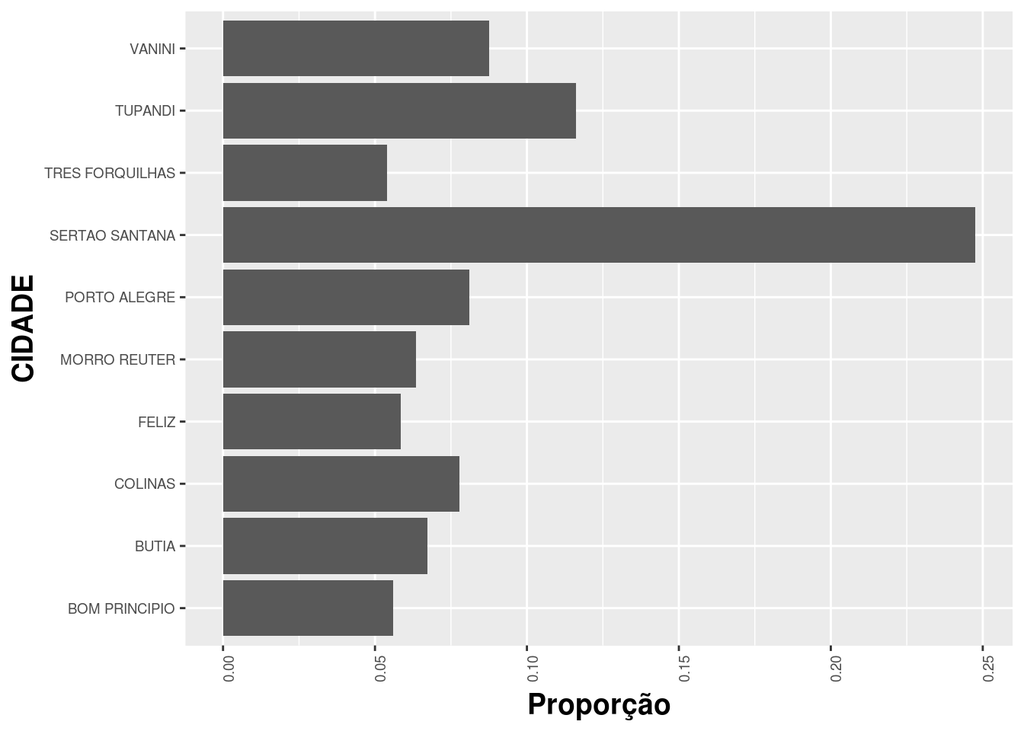

```r
group_cidade %>%
  head(n = 10) %>%
  ggplot(mapping = aes(x = CIDADE, y = PROPORCAO))+
  geom_bar(stat = "identity")+
  ylab("Proporção")+
  coord_flip()+
  theme(axis.text=element_text(size=7),
        axis.text.x = element_text(angle = 90, hjust = 1),
        axis.title=element_text(size=14,face="bold"))
```

#### Agrupamento por CIDADE e SEXO Para agrupamento por cidade, vamos fazer diferente, vamos dividir nosso dataset em dois, pois temos os casos de mulheres e homens, provavelmente a proporção de doação será diferente em uma mesma cidade para homens e para mulheres.

```r
# Começamos agrupando o nosso dataset por sexo.
group_cidade_sexo <- group_by(doacoes, CIDADE, TOTAL, TOTAL_H, TOTAL_M, SEXO)%>%
  summarise(DOACOES=n())

group_cidade_sexo$PROPORCAO <- group_cidade_sexo$DOACOES/group_cidade_sexo$TOTAL

#Ok, agora precisamos separar mulheres e homens já aproveitando para remover dados incompletos.
group_cidade_homens <- subset(group_cidade_sexo, SEXO == 'M')
group_cidade_homens <- group_cidade_homens[complete.cases(group_cidade_homens[,1:7]),]

group_cidade_mulheres <- subset(group_cidade_sexo, SEXO == 'F')
group_cidade_mulheres <- group_cidade_mulheres[complete.cases(group_cidade_mulheres[,1:7]),]

#Agora vamos filtrar somente as 10 cidades com maiores proporções de doação para cada sexo.
group_cidade_homens <- group_cidade_homens %>%
  arrange(-PROPORCAO) %>%
  head(n=10)

group_cidade_mulheres <- group_cidade_mulheres %>%
  arrange(-PROPORCAO) %>%
  head(n=10)

#Pronto, agora vamos agrupar novamente os dados para então plotarmos esses valores.
group_cidade_sexo <- dplyr::union(group_cidade_homens, group_cidade_mulheres)

head(group_cidade_sexo)
```

| CIDADE | TOTAL | TOTAL_H | TOTAL_M | SEXO | DOACOES | PROPORCAO |
| --- | --- | --- | --- | --- | --- | --- |
| BOM RETIRO DO SUL | 9624 | 4851 | 4773 | F | 243 | 0.02524938 |
| SANTA MARIA DO HERVAL | 5427 | 2849 | 2578 | F | 139 | 0.02561268 |
| COLINAS | 2236 | 1133 | 1103 | F | 61 | 0.02728086 |
| BOM PRINCIPIO | 10537 | 5406 | 5131 | F | 296 | 0.02809149 |
| BUTIA | 16424 | 8179 | 8245 | F | 513 | 0.03123478 |
| PORTO ALEGRE | 1140740 | 526746 | 613994 | F | 37091 | 0.03251486 |

#### As cidades com maior proporção de doações por habitantes separados por sexo

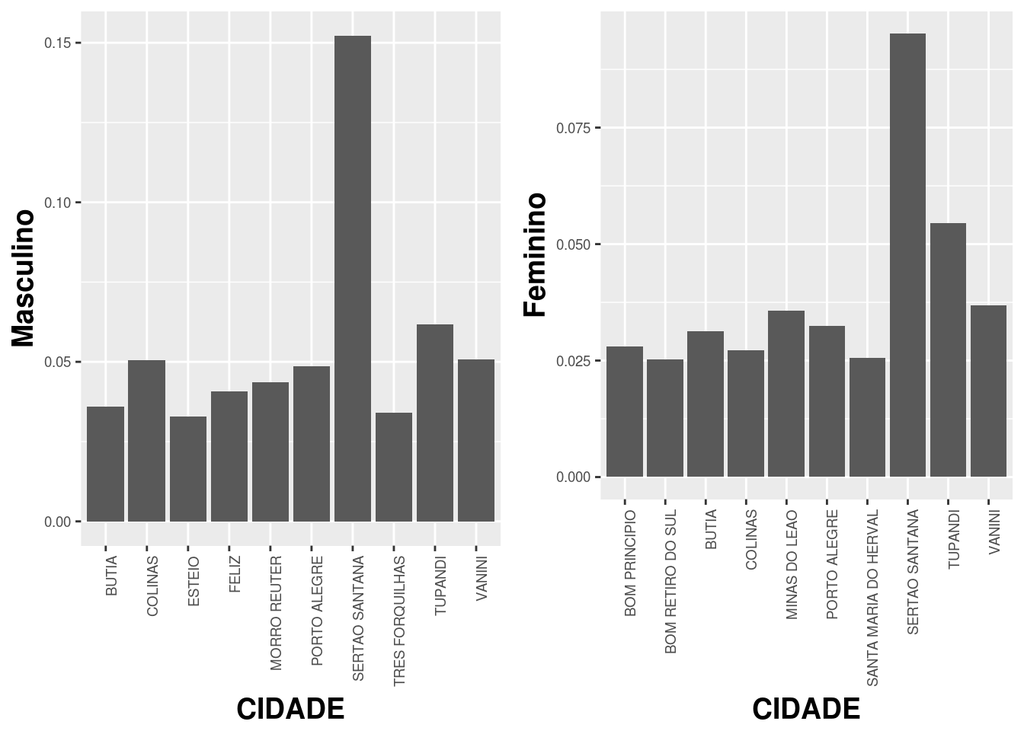

```r
plot_m <- group_cidade_sexo %>%
  subset(SEXO == 'M') %>%
  ggplot(mapping = aes(x = CIDADE, y = PROPORCAO))+
  geom_bar(stat = "identity")+
  ylab("Masculino")+
  theme(axis.text=element_text(size=7),
        axis.text.x = element_text(angle = 90, hjust = 1),
        axis.title=element_text(size=14,face="bold"))

plot_f <- group_cidade_sexo %>%
  subset(SEXO == 'F') %>%
  ggplot(mapping = aes(x = CIDADE, y = PROPORCAO))+
  geom_bar(stat = "identity")+
  ylab("Feminino")+
  theme(axis.text=element_text(size=7),
        axis.text.x = element_text(angle = 90, hjust = 1),
        axis.title=element_text(size=14,face="bold"))


grid.arrange(plot_m, plot_f, ncol = 2)
```

#### Exibindo proporção de doações para cada gênero em todas as 10 cidades com maior proporção para cada gênero

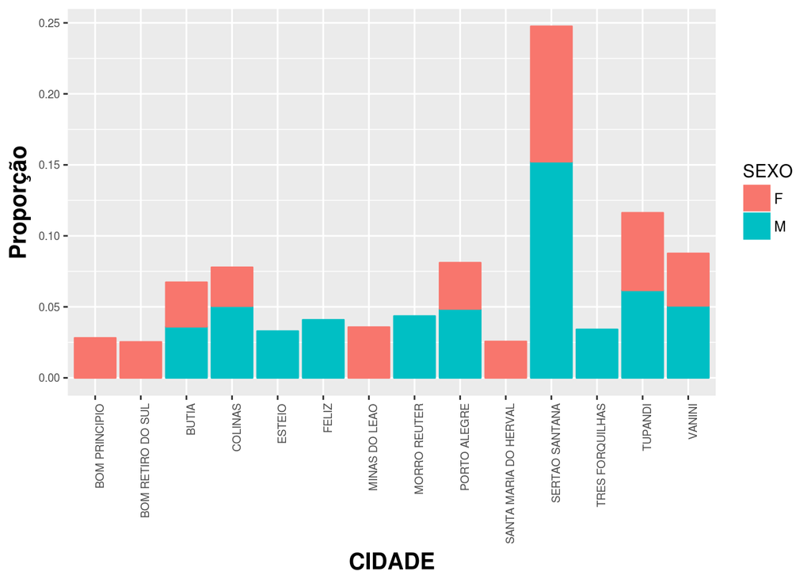

```r
group_cidade_sexo %>%
  subset(CIDADE %in% group_cidade_sexo$CIDADE) %>%
  ggplot(mapping = aes(x = CIDADE, y = PROPORCAO, color= SEXO, fill=SEXO))+
  geom_bar(stat = "identity")+
  ylab("Proporção")+
  theme(axis.text=element_text(size=7),
        axis.text.x = element_text(angle = 90, hjust = 1),
        axis.title=element_text(size=14,face="bold"))
```

### Tipos de doações

#### Tipo de doações onde homens tiveram 100% de doações

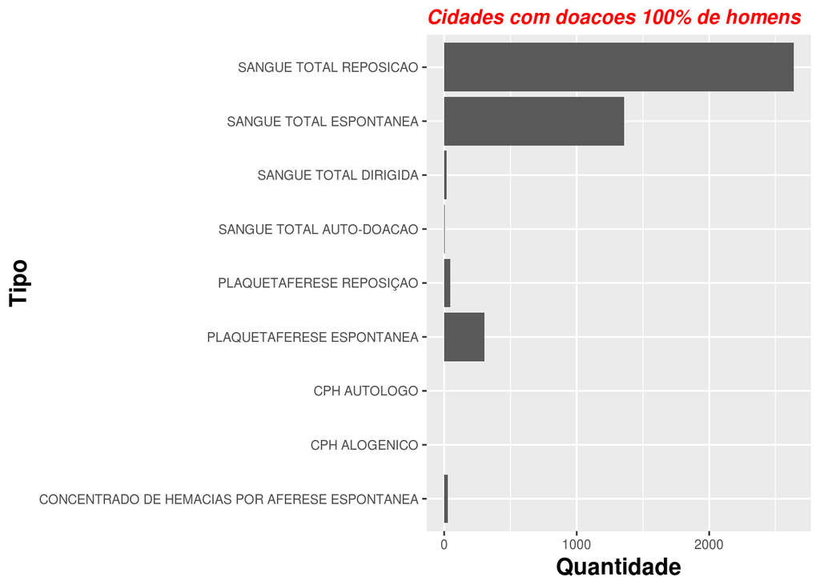

```r
nomes <- c("ESTEIO", "MORRO REUTER", "FELIZ", "TRES FORQUILHAS")

doacoes %>%
  filter(CIDADE %in% nomes) %>%
  ggplot(mapping = aes(x = TIPO_DOACAO))+
  geom_bar()+
  labs(title="Cidades com doacoes 100% de homens")+
  ylab("Quantidade")+
  xlab("Tipo")+
  coord_flip()+
  theme(axis.text=element_text(size=8),
        plot.title = element_text(color="red", size=12, face="bold.italic"),
        axis.title=element_text(size=14,face="bold"))
```

#### Tipo de doações onde mulheres tiveram 100% de doações

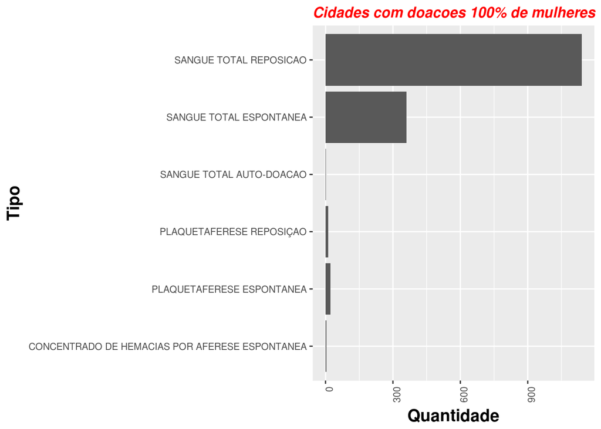

```r
nomes <- c("BOM PRINCIPIO", "BOM RETIRO DO SUL", "SANTA MARIA DO HERVAL", "MINAS DO LEAO")

doacoes %>%
  filter(CIDADE %in% nomes) %>%
  ggplot(mapping = aes(x = TIPO_DOACAO))+
  geom_bar()+
  labs(title="Cidades com doacoes 100% de mulheres")+
  ylab("Quantidade")+
  xlab("Tipo")+
  coord_flip()+
  theme(axis.text=element_text(size=8),
        plot.title = element_text(color="red", size=12, face="bold.italic"),
        axis.text.x = element_text(angle = 90, hjust = 1),
        axis.title=element_text(size=14,face="bold"))
```

#### Quantidade de doações x Tipo x Sexo

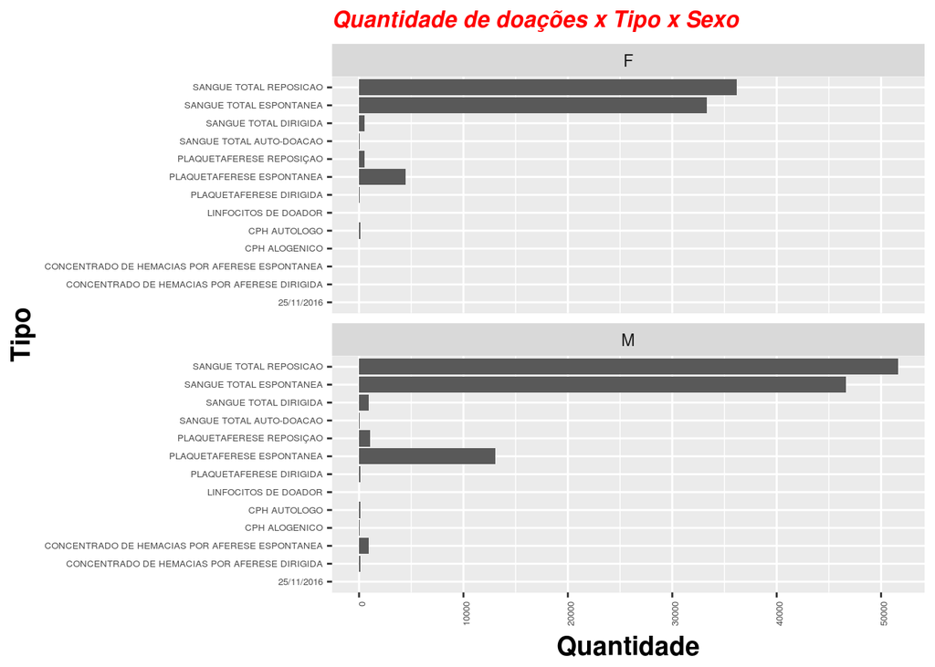

```r
doacoes %>%
  ggplot(mapping = aes(x = TIPO_DOACAO))+
  geom_bar()+
  labs(title="Quantidade de doações x Tipo x Sexo")+
  ylab("Quantidade")+
  xlab("Tipo")+
  coord_flip()+
  theme(axis.text=element_text(size=5),
        plot.title = element_text(color="red", size=12, face="bold.italic"),
        axis.text.x = element_text(angle = 90, hjust = 1),
        axis.title=element_text(size=14,face="bold"))+
  facet_wrap(~ SEXO, ncol = 1)
```

Em ambos os sexos temos mais doações do tipo ‘Sangue total reposição’ e ‘Sangue total espontânea’ com o tipo ‘Plaquetaferese espontânea’ como o terceiro mais citado. Por mais que as doações por reposição sejam a maioria, temos que notar que doações onde a mesma é feita de forma espontânea (ou seja, sem a intenção de ajudar alguém específico) está bem próxima das doações feitas com ojetivando alguém.  
Vamos agora focar na cidade com maior proporção de doações para verificar se temos algum padrão ou mesmo se conseguiremos identificar algum padrão.

#### Analizando o cenário de Sertão Santana - Tipo Sanguíneo

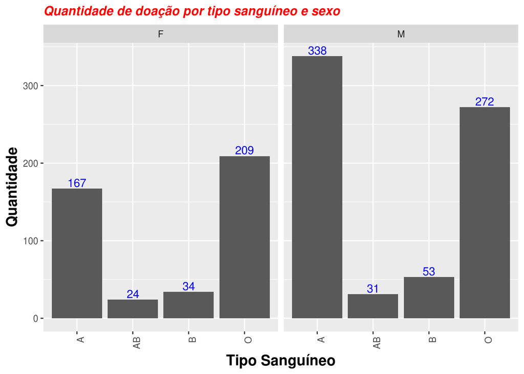

```r
tipo_sangue <- subset(doacoes, CIDADE == 'SERTAO SANTANA') %>%
  group_by(ABO_DOADOR, SEXO)%>%
  summarise(QUANTIDADE=n())

tipo_sangue%>%
 ggplot(mapping = aes(x = ABO_DOADOR, y = QUANTIDADE))+
 geom_bar(stat = "identity")+
  geom_text(aes(label=QUANTIDADE), vjust=-0.2, color="blue") +
 labs(title="Quantidade de doação por tipo sanguíneo e sexo")+
 ylab("Quantidade")+
 xlab("Tipo Sanguíneo")+
 theme(plot.title = element_text(color="red", size=12, face="bold.italic"),
       axis.text.x = element_text(angle = 90, hjust = 1),
       axis.title=element_text(size=14,face="bold"))+
  facet_wrap(~SEXO, ncol=2)
```

#### Tipo de Doação em Sertão Santana

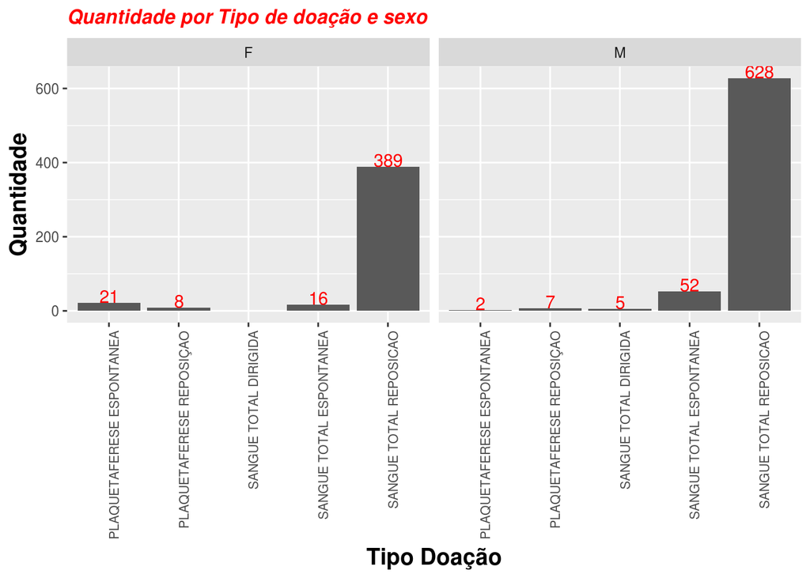

```r
doacoes %>%
 subset(CIDADE == 'SERTAO SANTANA') %>%
 group_by(TIPO_DOACAO, SEXO)%>%
 summarise(QUANTIDADE=n())%>%
 ggplot(mapping = aes(x = TIPO_DOACAO, y = QUANTIDADE))+
  geom_bar(stat = "identity")+
  geom_text(aes(label=QUANTIDADE), vjust=0, color="red") +
  labs(title="Quantidade por Tipo de doação e sexo")+
  ylab("Quantidade")+
  xlab("Tipo Doação")+
  theme(plot.title = element_text(color="red", size=12, face="bold.italic"),
       axis.text.x = element_text(angle = 90, hjust = 1, size = 8),
       axis.title=element_text(size=14,face="bold"))+
  facet_wrap(~SEXO, ncol=2)
```

Aqui podemos ver o que a maioria das doações foram para Reposição, ou seja, com o foco em alguém específico. Tivemos algumas doações espontâneas, mas nem se compara com o comportamento encontrado na análise geral. Vamos analisar o período de tais doações, verificar se tais doações tiveram um acúmulo em um período específico ou não.

#### Analisando o período das doações de Sertão Santana

Vamos analisar o período em que ocorreram as doações da população de Sertão Santana, para então tentar localizar o possível motivo que fez com que uma cidade pequena tivesse um case tão peculiar de doações.

```r
# Começamos primeiro filtrando os resultados referentes a S. Santana

sertao_santana <- doacoes %>%
 subset(CIDADE == 'SERTAO SANTANA' & ABO_DOADOR != 'NULL')

head(sertao_santana)
```

|  | RACA | SEXO | DATA_NASC | ESTADO_CIVIL | ESCOLARIDADE | PROFISSAO | COR | CIDADE | BAIRRO | C_PROFISSIONAL | B_PROFISSIONAL | NATURALIDADE | NACIONALIDADE | ABO_DOADOR | RH_DOADOR | DOD_HEMOGLOBINAS | DOD_CDE | PAI | DT_DOACAO | TIPO_DOACAO | CAMPANHA | DESISTENCIA_DOACAO | DOA_PESO | DOA_ALTURA | DOA_TEMPERATURA | DOA_PULSO | DOA_HEMOGLOBINA | DOA_PRESSAOARTERIAL1 | DOA_PRESSAOARTERIAL2 | … |
| --- | --- | --- | --- | --- | --- | --- | --- | --- | --- | --- | --- | --- | --- | --- | --- | --- | --- | --- | --- | --- | --- | --- | --- | --- | --- | --- | --- | --- | --- | --- |
| 266 | Branco | M | 13/10/1987 | Casado | Ens. Medio Completo | OUTROS | M4 | SERTAO SANTANA | PIRAPO | PORTO ALEGRE | RIO BRANCO | TAPES | BRASILEIRO | AB | + | NULL | + | N | 04/07/2015 | SANGUE TOTAL REPOSICAO | NULL | N | NULL | 1690 | 36000 | 60000 | 16000 | 117000 | 72000 | … |
| 1470 | Branco | M | 18/08/1948 | Casado | Ens. Medio Completo | Aposentado | M4 | SERTAO SANTANA | DOBRADA | PORTO ALEGRE | RIO BRANCO | HORIZONTINA | BRASILEIRO | AB | + | NULL | + | N | 05/05/2015 | SANGUE TOTAL REPOSICAO | NULL | N | NULL | 1780 | 36000 | 74000 | 16000 | 154000 | 84000 | … |
| 1475 | Branco | M | 18/08/1948 | Casado | Ens. Medio Completo | Aposentado | M4 | SERTAO SANTANA | DOBRADA | PORTO ALEGRE | RIO BRANCO | HORIZONTINA | BRASILEIRO | AB | + | NULL | + | N | 05/05/2015 | SANGUE TOTAL REPOSICAO | NULL | N | NULL | 1780 | 36000 | 74000 | 16000 | 154000 | 84000 | … |
| 1504 | Negro | M | 20/01/1982 | Solteiro | Ens. Fundamental Incompleto | OUTROS | M6 | SERTAO SANTANA | INTERIOR | PORTO ALEGRE | RIO BRANCO | TAPES | BRASILEIRO | A | - | Ausente | - | N | 17/06/2015 | SANGUE TOTAL REPOSICAO | NULL | N | NULL | 1700 | 37000 | 81000 | 15000 | 119000 | 85000 | … |
| 1548 | Branco | M | 18/08/1948 | Casado | Ens. Medio Completo | Aposentado | M4 | SERTAO SANTANA | DOBRADA | PORTO ALEGRE | RIO BRANCO | HORIZONTINA | BRASILEIRO | AB | + | NULL | + | N | 05/05/2015 | SANGUE TOTAL REPOSICAO | NULL | N | NULL | 1780 | 36000 | 74000 | 16000 | 154000 | 84000 | … |
| 1609 | Branco | M | 25/09/1982 | Casado | Ens. Medio Completo | OPERADOR DE MAQUINAS | M4 | SERTAO SANTANA | Centro | PORTO ALEGRE | RIO BRANCO | SERTÃO SANTANA | Brasil | A | + | NULL | + | N | 04/07/2015 | SANGUE TOTAL REPOSICAO | NULL | N | NULL | 1800 | 36000 | 62000 | 15000 | 130000 | 67000 | … |

```r
# Primeiro convertemos a data de factor para Date
sertao_santana$DT_DOACAO <- as.Date(sertao_santana$DT_DOACAO, format = "%d/%m/%Y")
head(sertao_santana)
```

|  | RACA | SEXO | DATA_NASC | ESTADO_CIVIL | ESCOLARIDADE | PROFISSAO | COR | CIDADE | BAIRRO | C_PROFISSIONAL | B_PROFISSIONAL | NATURALIDADE | NACIONALIDADE | ABO_DOADOR | RH_DOADOR | DOD_HEMOGLOBINAS | DOD_CDE | PAI | DT_DOACAO | TIPO_DOACAO | CAMPANHA | DESISTENCIA_DOACAO | DOA_PESO | DOA_ALTURA | DOA_TEMPERATURA | DOA_PULSO | DOA_HEMOGLOBINA | DOA_PRESSAOARTERIAL1 | DOA_PRESSAOARTERIAL2 | … |
| --- | --- | --- | --- | --- | --- | --- | --- | --- | --- | --- | --- | --- | --- | --- | --- | --- | --- | --- | --- | --- | --- | --- | --- | --- | --- | --- | --- | --- | --- | --- |
| 266 | Branco | M | 13/10/1987 | Casado | Ens. Medio Completo | OUTROS | M4 | SERTAO SANTANA | PIRAPO | PORTO ALEGRE | RIO BRANCO | TAPES | BRASILEIRO | AB | + | NULL | + | N | 2015-07-04 | SANGUE TOTAL REPOSICAO | NULL | N | NULL | 1690 | 36000 | 60000 | 16000 | 117000 | 72000 | … |
| 1470 | Branco | M | 18/08/1948 | Casado | Ens. Medio Completo | Aposentado | M4 | SERTAO SANTANA | DOBRADA | PORTO ALEGRE | RIO BRANCO | HORIZONTINA | BRASILEIRO | AB | + | NULL | + | N | 2015-05-05 | SANGUE TOTAL REPOSICAO | NULL | N | NULL | 1780 | 36000 | 74000 | 16000 | 154000 | 84000 | … |
| 1475 | Branco | M | 18/08/1948 | Casado | Ens. Medio Completo | Aposentado | M4 | SERTAO SANTANA | DOBRADA | PORTO ALEGRE | RIO BRANCO | HORIZONTINA | BRASILEIRO | AB | + | NULL | + | N | 2015-05-05 | SANGUE TOTAL REPOSICAO | NULL | N | NULL | 1780 | 36000 | 74000 | 16000 | 154000 | 84000 | … |
| 1504 | Negro | M | 20/01/1982 | Solteiro | Ens. Fundamental Incompleto | OUTROS | M6 | SERTAO SANTANA | INTERIOR | PORTO ALEGRE | RIO BRANCO | TAPES | BRASILEIRO | A | - | Ausente | - | N | 2015-06-17 | SANGUE TOTAL REPOSICAO | NULL | N | NULL | 1700 | 37000 | 81000 | 15000 | 119000 | 85000 | … |
| 1548 | Branco | M | 18/08/1948 | Casado | Ens. Medio Completo | Aposentado | M4 | SERTAO SANTANA | DOBRADA | PORTO ALEGRE | RIO BRANCO | HORIZONTINA | BRASILEIRO | AB | + | NULL | + | N | 2015-05-05 | SANGUE TOTAL REPOSICAO | NULL | N | NULL | 1780 | 36000 | 74000 | 16000 | 154000 | 84000 | … |
| 1609 | Branco | M | 25/09/1982 | Casado | Ens. Medio Completo | OPERADOR DE MAQUINAS | M4 | SERTAO SANTANA | Centro | PORTO ALEGRE | RIO BRANCO | SERTÃO SANTANA | Brasil | A | + | NULL | + | N | 2015-07-04 | SANGUE TOTAL REPOSICAO | NULL | N | NULL | 1800 | 36000 | 62000 | 15000 | 130000 | 67000 | … |

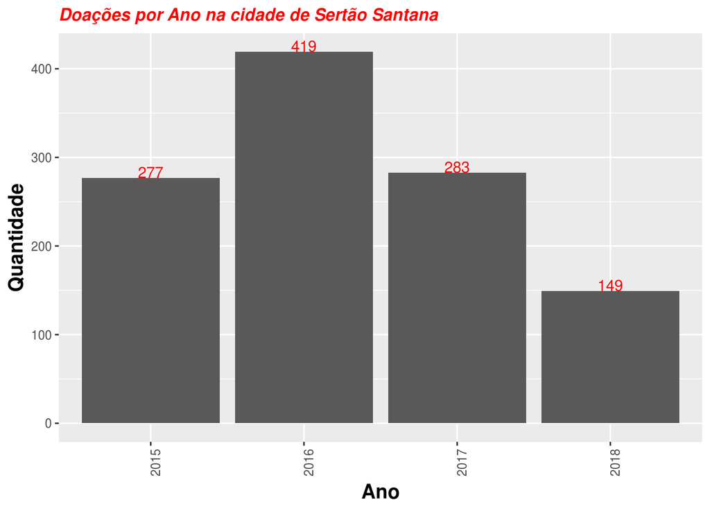

```r
sertao_santana$MONTH <- factor(month(sertao_santana$DT_DOACAO))
sertao_santana$YEAR <- factor(year(sertao_santana$DT_DOACAO))

sertao_santana %>%
  group_by(YEAR)%>%
  summarise(QUANTIDADE=n())%>%
  ggplot(mapping = aes(x = YEAR, y = QUANTIDADE))+
    geom_bar(stat = "identity")+
    geom_text(aes(label=QUANTIDADE), vjust=0, color="red") +
    labs(title="Doações por Ano na cidade de Sertão Santana")+
    ylab("Quantidade")+
    xlab("Ano")+
    theme(plot.title = element_text(color="red", size=12, face="bold.italic"),
         axis.text.x = element_text(angle = 90, hjust = 1),
         axis.title=element_text(size=14,face="bold"))
```

Agora vamos analisar o caso de doações por mês.

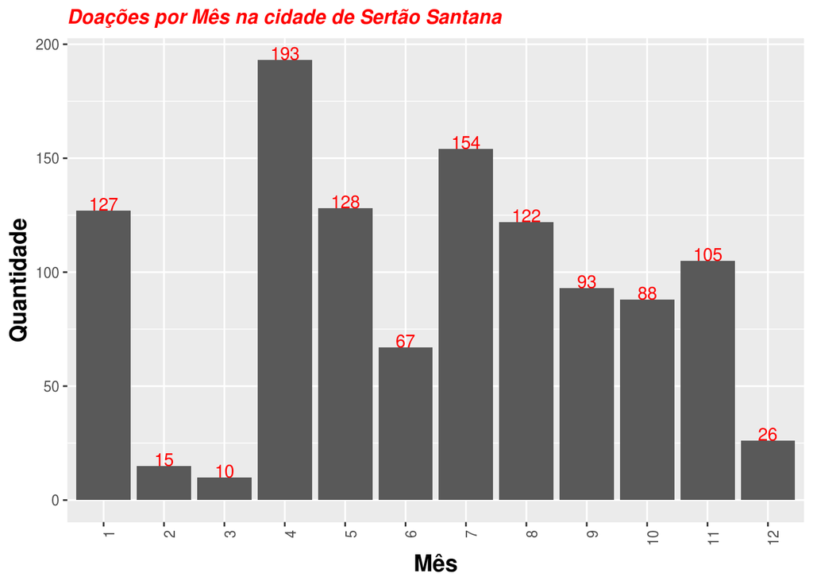

```r
sertao_santana %>%
  group_by(MONTH)%>%
  summarise(QUANTIDADE=n())%>%
  ggplot(mapping = aes(x = MONTH, y = QUANTIDADE))+
    geom_bar(stat = "identity")+
    geom_text(aes(label=QUANTIDADE), vjust=0, color="red") +
    labs(title="Doações por Mês na cidade de Sertão Santana")+
    ylab("Quantidade")+
    xlab("Mês")+
    theme(plot.title = element_text(color="red", size=12, face="bold.italic"),
         axis.text.x = element_text(angle = 90, hjust = 1),
         axis.title=element_text(size=14,face="bold"))
```

Não conseguimos ter uma ideia de destaque nesses dados, talvez se pegarmos o ano com mais doações e nesse ano analisarmos a quantidade de doações por mês possamos encontrar algum caso onde tenhamos uma quantidade maior de doações. Vamos pegar o caso de 2016, onde temos quase 50% a mais de doações que os demais anos.

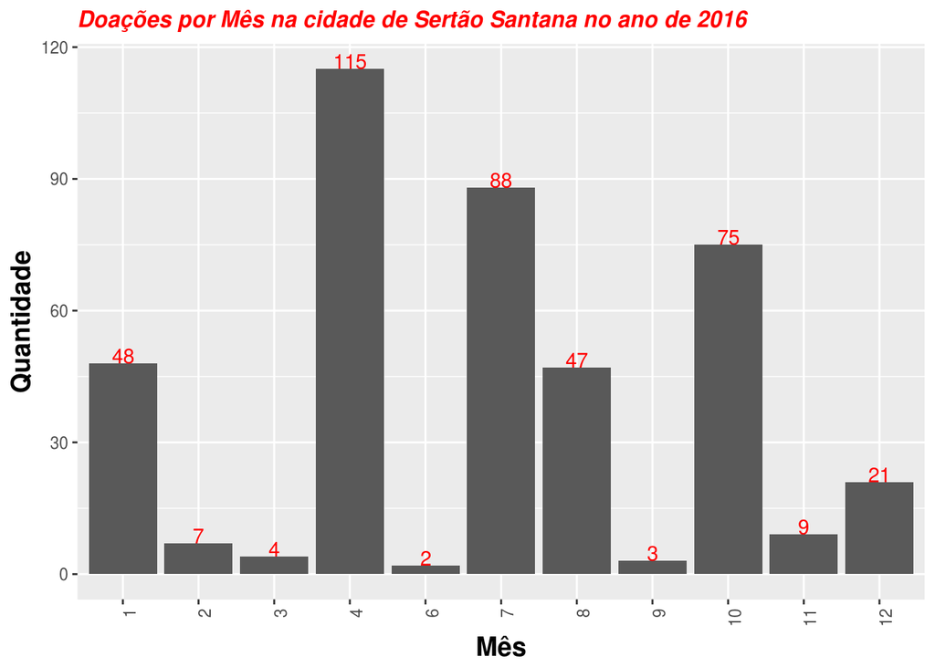

```r
sertao_santana %>%
  subset(YEAR == '2016') %>%
  group_by(MONTH)%>%
  summarise(QUANTIDADE=n())%>%
  ggplot(mapping = aes(x = MONTH, y = QUANTIDADE))+
    geom_bar(stat = "identity")+
    geom_text(aes(label=QUANTIDADE), vjust=0, color="red") +
    labs(title="Doações por Mês na cidade de Sertão Santana no ano de 2016")+
    ylab("Quantidade")+
    xlab("Mês")+
    theme(plot.title = element_text(color="red", size=12, face="bold.italic"),
         axis.text.x = element_text(angle = 90, hjust = 1),
         axis.title=element_text(size=14,face="bold"))
```

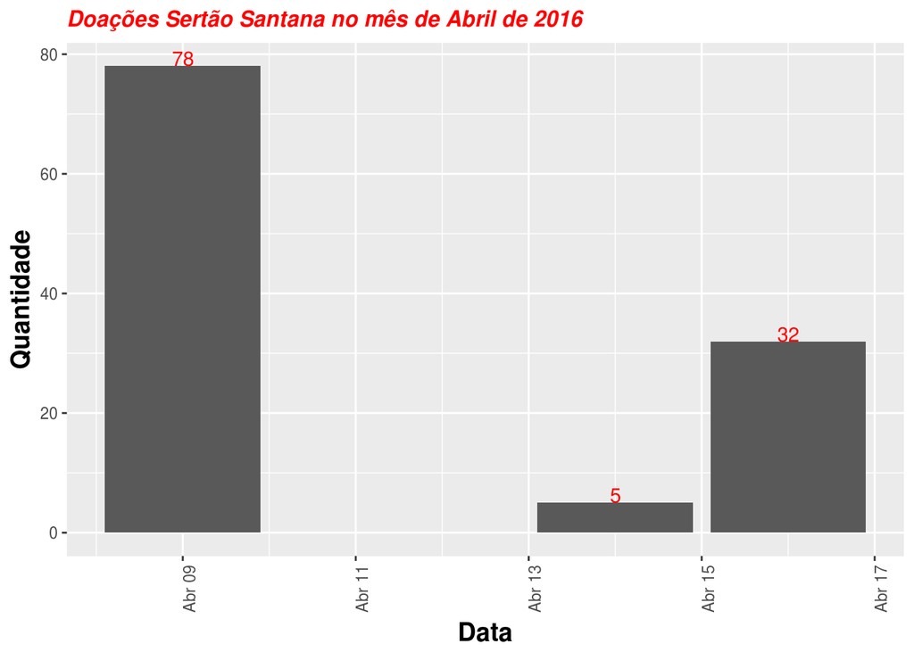

```r
sertao_santana %>%
  subset(YEAR == '2016' & MONTH == "4" ) %>%
  group_by(DT_DOACAO)%>%
  summarise(QUANTIDADE=n())%>%
  ggplot(mapping = aes(x = DT_DOACAO, y = QUANTIDADE))+
    geom_bar(stat = "identity")+
    geom_text(aes(label=QUANTIDADE), vjust=0, color="red") +
    labs(title="Doações Sertão Santana no mês de Abril de 2016")+
    ylab("Quantidade")+
    xlab("Data")+
    theme(plot.title = element_text(color="red", size=12, face="bold.italic"),
         axis.text.x = element_text(angle = 90, hjust = 1),
         axis.title=element_text(size=14,face="bold"))
```

O interessante aqui é que temos 78 doações no dia 9 de abril. Uma quantidade bem anormal para uma cidade de 5 mil habitantes. Vamos analisar o tipo sanguíneo dos doadores.

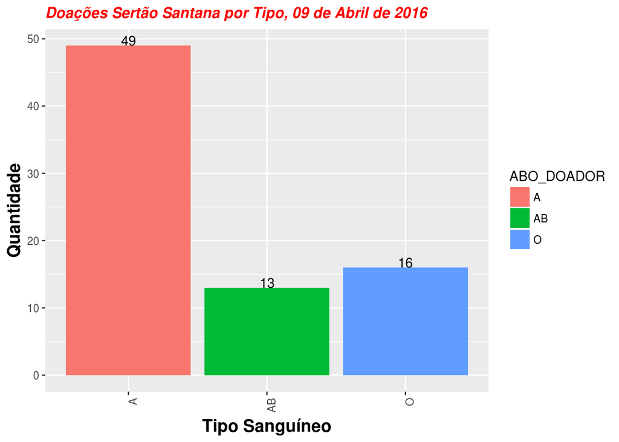

```r
sertao_santana %>%
  subset(DT_DOACAO == as.Date('2016-04-09')) %>%
  group_by(ABO_DOADOR)%>%
  summarise(QUANTIDADE=n())%>%
  ggplot(mapping = aes(x = ABO_DOADOR, y = QUANTIDADE, fill = ABO_DOADOR))+
    geom_bar(stat = "identity")+
    geom_text(aes(label=QUANTIDADE), vjust=0) +
    labs(title="Doações Sertão Santana por Tipo, 09 de Abril de 2016")+
    ylab("Quantidade")+
    xlab("Tipo Sanguíneo")+
    theme(plot.title = element_text(color="red", size=12, face="bold.italic"),
         axis.text.x = element_text(angle = 90, hjust = 1),
         axis.title=element_text(size=14,face="bold"))
```

Temos um padrão aqui, segundo o site da Cruz Vermelha(https://www.redcrossblood.org/donate-blood/how-to-donate/types-of-blood-donations/blood-types.html#), pessoas do tipo sanguíneo A, AB e O podem doar todas em específico para o tipo sanguíneo AB.

```r
maior_prop_doacoes <- subset(doacoes, CIDADE == 'SERTAO SANTANA')
```

### Doações e Idade

#### Criando função para calcular a idade dos doadores

Nosso dataset não possuí a idade dos doadores já calculad, mas possuí a data de nascimento. Vamos então criar uma função para calcular a idade dos doadores.

```r
calc_idade <- function(data_str) {
  data_nasc <- as.Date(as.character(data_str), format="%d/%m/%Y")
  years <- as.numeric(difftime(Sys.Date(), data_nasc, unit="weeks"))/52.25
  return(as.numeric(round(years)))
}
```

#### Aplicando função no DF

```r
doacoes$IDADE <- sapply(doacoes$DATA_NASC, calc_idade)
summary(doacoes$IDADE)
```

```
##    Min. 1st Qu.  Median    Mean 3rd Qu.    Max.
##     2.0    29.0    37.0    38.5    47.0    73.0
```

#### Distribuição de doações por idade e sexo Vamos analisar a distribuição de idade dos doadores, novamente agrupado por sexo.

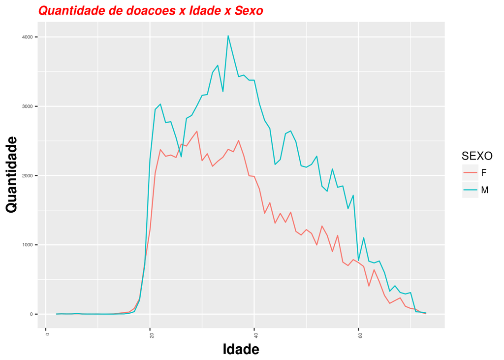

```r
doacoes %>%
  group_by(IDADE, SEXO)%>%
  summarise(DOACOES=n()) %>%
  ggplot(mapping = aes(x = IDADE, y = DOACOES, color=SEXO))+
  geom_line()+
  labs(title="Quantidade de doacoes x Idade x Sexo")+
  ylab("Quantidade")+
  xlab("Idade")+
  theme(axis.text=element_text(size=5),
        plot.title = element_text(color="red", size=12, face="bold.italic"),
        axis.text.x = element_text(angle = 90, hjust = 1),
        axis.title=element_text(size=14,face="bold"))
```

#### Distribuição de idade entre os doados agrupados por sexo

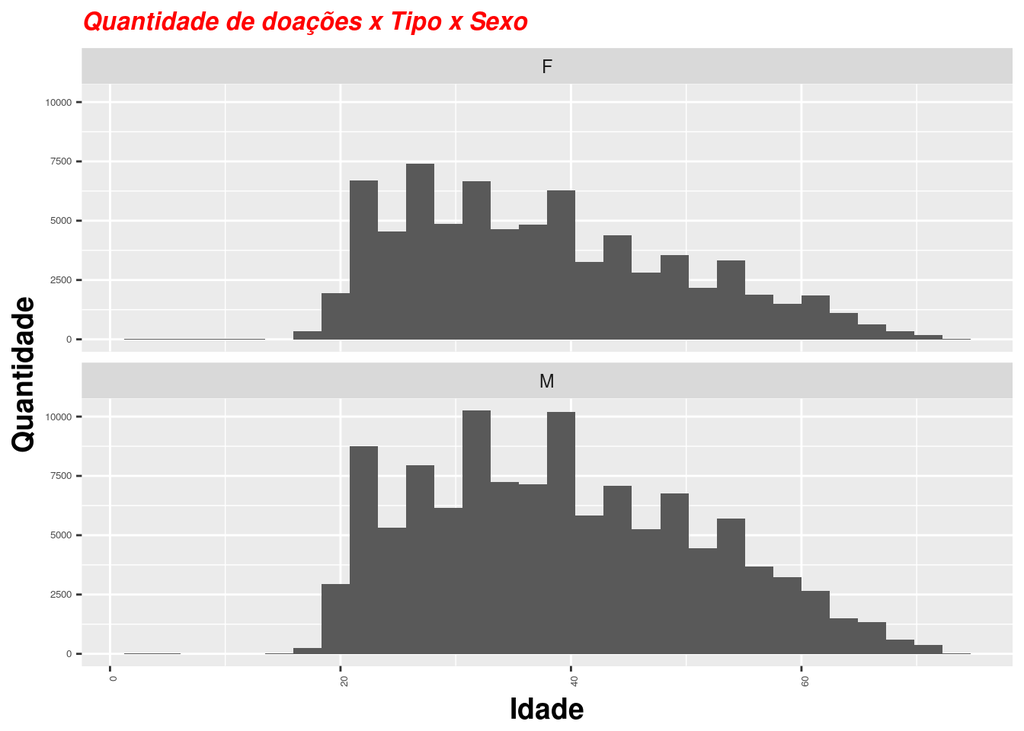

```r
doacoes %>%
  ggplot(mapping = aes(x = IDADE))+
  geom_histogram()+
  labs(title="Quantidade de doações x Tipo x Sexo")+
  ylab("Quantidade")+
  xlab("Idade")+
  theme(axis.text=element_text(size=5),
        plot.title = element_text(color="red", size=12, face="bold.italic"),
        axis.text.x = element_text(angle = 90, hjust = 1),
        axis.title=element_text(size=14,face="bold"))+
  facet_wrap(~ SEXO, ncol = 1)
```

#### Analisando as doações da cidade de Porto Alegre

```r
poa_df <- doacoes %>%
  subset(doacoes$CIDADE == 'PORTO ALEGRE' & doacoes$BAIRRO != 'NULL' & !is.null(doacoes$BAIRRO))

poa_df$BAIRRO <- as.factor(poa_df$BAIRRO)
print('Sumário por bairros.')
```

```
## [1] "Sumário por bairros."
```

```r
head(summary(poa_df$BAIRRO))
```

```
##     PETROPOLIS     RIO BRANCO PROTASIO ALVES    RUBEM BERTA        Santana
##           5282           4513           4304           3920           3526
##       PARTENON
##           2882
```

#### Filtrando bairros

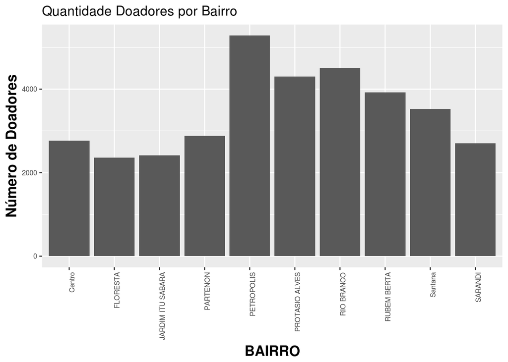

```r
poa_bairros_df <- poa_df[ poa_df$BAIRRO %in%  names(table(poa_df$BAIRRO))[table(poa_df$BAIRRO) > 2197] , ]

poa_bairros_df %>%
  ggplot(mapping = aes(x = BAIRRO))+
  geom_bar() +
  ylab("Número de Doadores")+
  labs(title="Quantidade Doadores por Bairro")+
  theme(axis.text=element_text(size=7),
        axis.text.x = element_text(angle = 90, hjust = 1),
        axis.title=element_text(size=14,face="bold"))
```

#### Filtrando bairros e agrupando por sexo

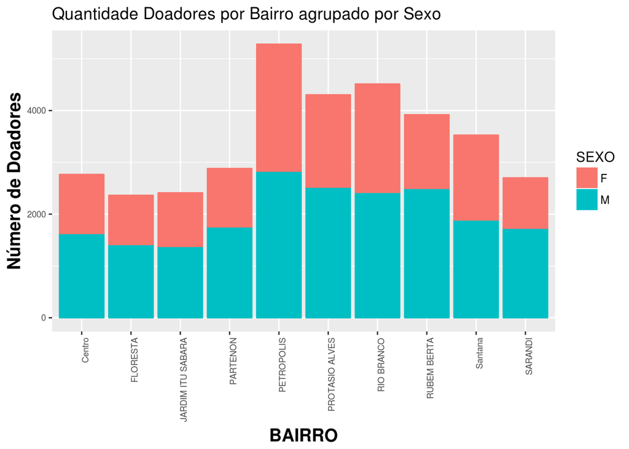

```r
poa_bairros_df %>%
  ggplot(mapping = aes(x = BAIRRO, color=SEXO, fill=SEXO))+
  geom_bar() +
  ylab("Número de Doadores")+
  labs(title="Quantidade Doadores por Bairro agrupado por Sexo")+
  theme(axis.text=element_text(size=7),
        axis.text.x = element_text(angle = 90, hjust = 1),
        axis.title=element_text(size=14,face="bold"))
```

#### Distribuição dos dados por idade

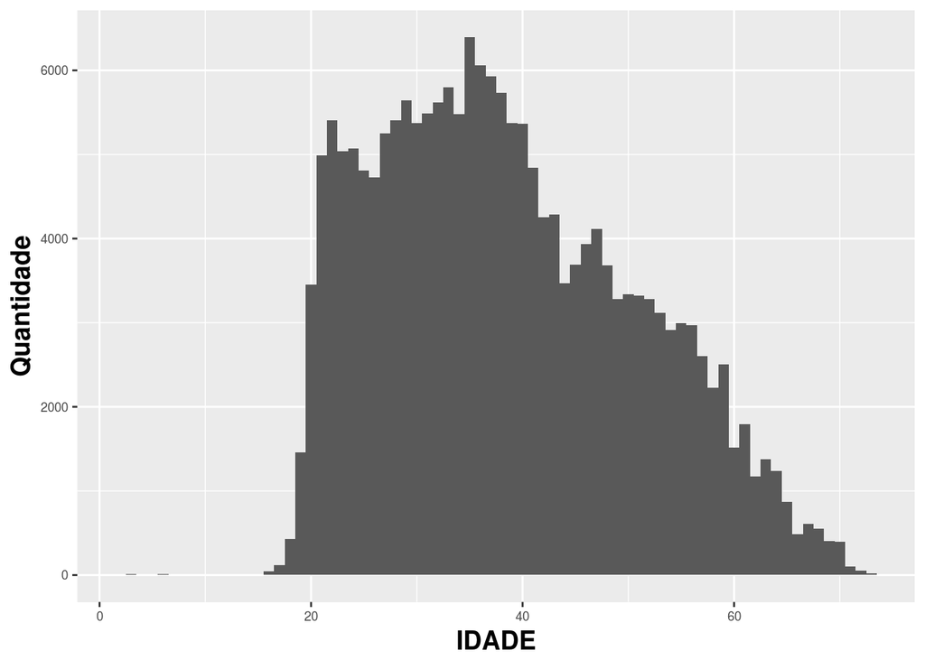

```r
doacoes %>%
  ggplot(mapping = aes(x = IDADE))+
  geom_histogram(binwidth = 1)+
  ylab("Quantidade")+
  theme(axis.text=element_text(size=7),
        axis.title=element_text(size=14,face="bold"))
```

#### Distribuição dos dados por idade e sexo

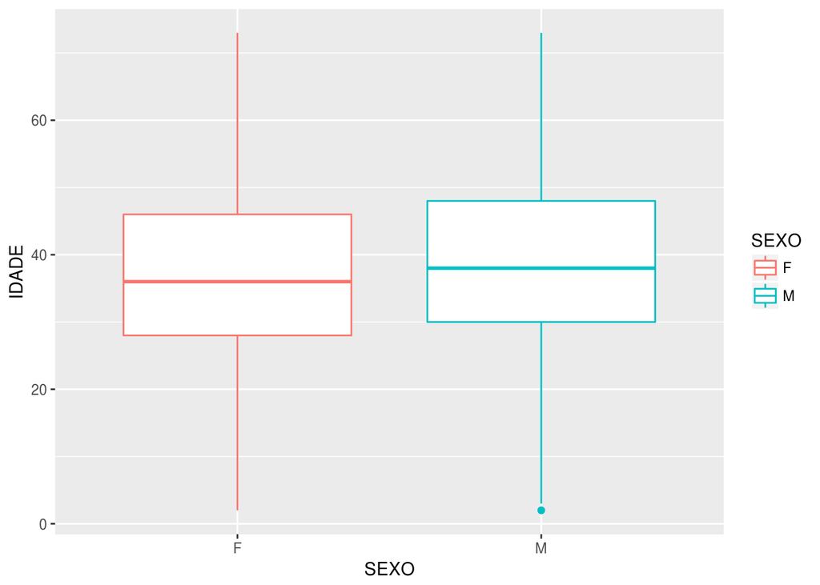

```r
doacoes %>%
  ggplot(mapping = aes(SEXO, IDADE, color=SEXO))+
  geom_boxplot()
```

#### Distribuição dos dados por idade e sexo

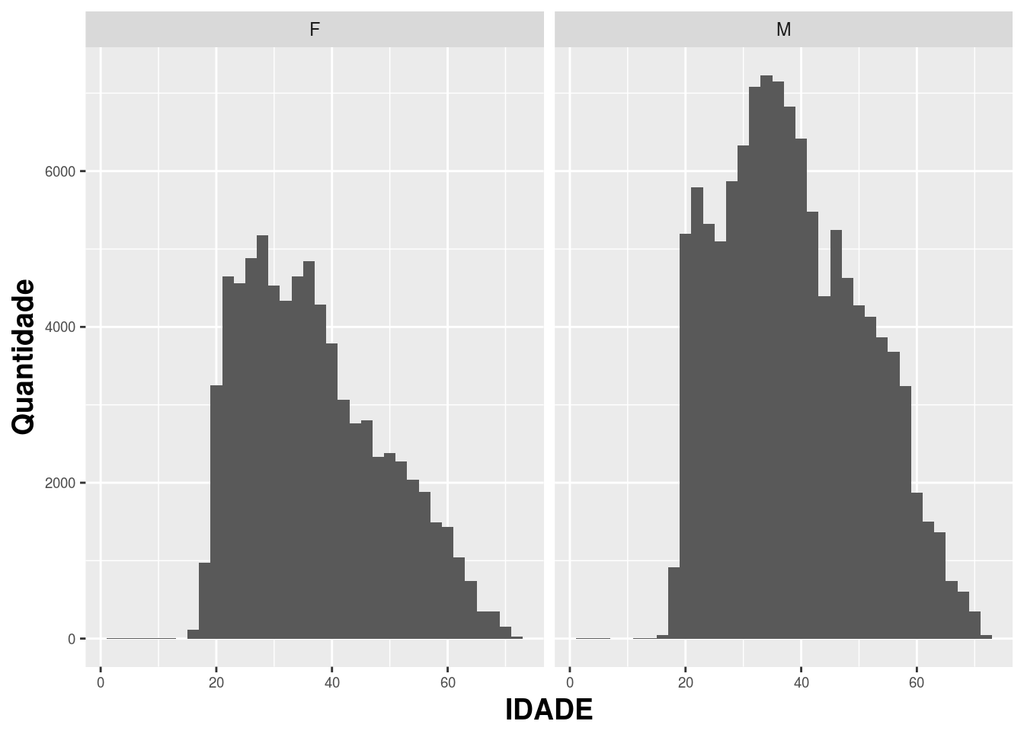

```r
doacoes %>%
  ggplot(mapping = aes(x = IDADE))+
  geom_histogram(binwidth = 2)+
  ylab("Quantidade")+
  theme(axis.text=element_text(size=7),
        axis.title=element_text(size=14,face="bold"))+
  facet_wrap( ~ SEXO, ncol = 2)
```

#### Distribuição dos dados por idade e sexo na cidade de Porto Alegre

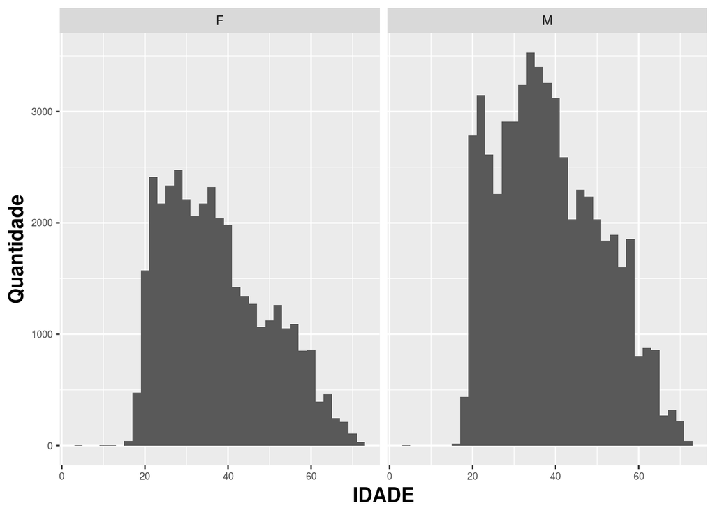

```r
doacoes %>%
  subset(CIDADE == 'PORTO ALEGRE') %>%
  ggplot(mapping = aes(x = IDADE))+
  geom_histogram(binwidth = 2)+
  ylab("Quantidade")+
  theme(axis.text=element_text(size=7),
        axis.title=element_text(size=14,face="bold"))+
  facet_wrap( ~ SEXO, ncol = 2)
```

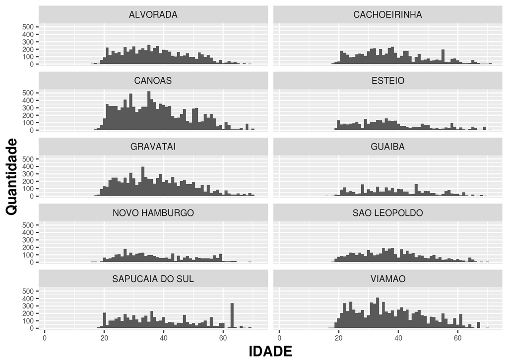

```r
doacoes[ doacoes$CIDADE %in%  names(table(doacoes$CIDADE))[table(doacoes$CIDADE) > 2197] , ] %>%
  subset(CIDADE != 'PORTO ALEGRE') %>%
  ggplot(mapping = aes(x = IDADE))+
  geom_histogram(binwidth = 1)+
  ylab("Quantidade")+
  theme(axis.text=element_text(size=7),
        axis.title=element_text(size=14,face="bold"))+
  facet_wrap( ~CIDADE, ncol = 2)
```

```r
# doacoes %>%
#  subset(CIDADE == 'SERTAO SANTANA' & ABO_DOADOR != 'NULL') %>%
#  dplyr::group_by(TIPO_DOACAO, ABO_DOADOR)%>%
#  dplyr::summarise(QUANTIDADE=n())%>%
#  ggplot(mapping = aes(x = TIPO_DOACAO, y = QUANTIDADE))+
#   geom_bar(stat = "identity")+
#   geom_text(aes(label=QUANTIDADE), vjust=0, color="red") +
#   labs(title="Quantidade por Tipo de doação e Tipo Sanguíneo")+
#   ylab("Quantidade")+
#   xlab("Tipo Doação")+
#   theme(plot.title = element_text(color="red", size=12, face="bold.italic"),
#        axis.text.x = element_text(angle = 90, hjust = 1),
#        axis.title=element_text(size=14,face="bold"))+
#   facet_wrap(~TIPO_SANGUE, ncol=2)
```